# Tugas Pertemuan 2

Muhammad Fauzan Nur Rasendriya (G1401231108)

04 September 2025

```r
install_load <- function (package1, ...){
   packages <- c(package1, ...)
   for(package in packages){
       if(package %in% rownames(installed.packages())){
         do.call('library', list(package))
       }
       else{
          install.packages(package)
          do.call("library", list(package))
       }
   }
}

install_load("knitr","showtext","rio","dplyr","TTR","forecast","lmtest","orcutt","HoRM","ggplot2","GGally")

opts_knit$set(root.dir = normalizePath("./"))

font_add_google("Lato", "lato")
showtext_auto()
```

# Data

```r
# Load Data CSV
url <- "https://raw.githubusercontent.com/fauzanrasendriya/MPDW/main/Pertemuan%202/IPM_Yogya_2010_2024.csv"
data <- import(url)

head(data)
```

|  | Tahun | Wilayah | IPM |
| --- | --- | --- | --- |
| 1 | 2010 | D I Yogyakarta | 75.37 |
| 2 | 2011 | D I Yogyakarta | 75.93 |
| 3 | 2012 | D I Yogyakarta | 76.15 |
| 4 | 2013 | D I Yogyakarta | 76.44 |
| 5 | 2014 | D I Yogyakarta | 76.81 |
| 6 | 2015 | D I Yogyakarta | 77.59 |

## Eksplorasi Awal

Sebelum melakukan regresi, akan diperlihatkan *plot time-series* dari IPM D.I. Yogyakarta Periode 2010-2024

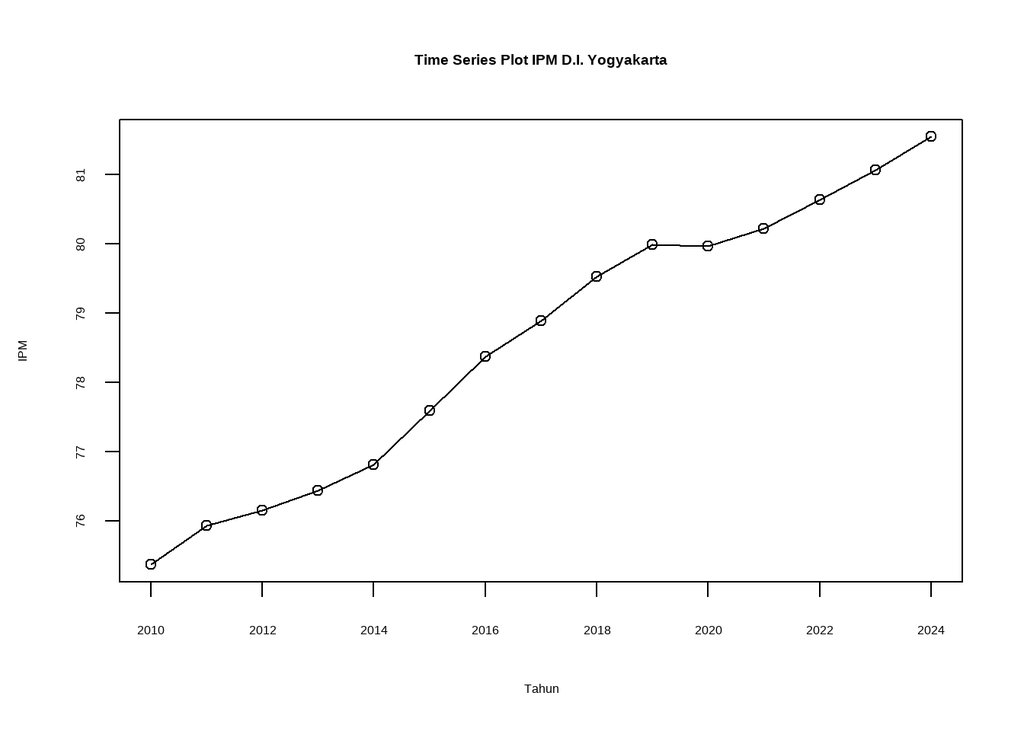

```r
# Membentuk objek time series
data.ts <- ts(data$IPM, start = min(data$Tahun), frequency = 1)

# Plot time series
ts.plot(data.ts, xlab = "Tahun", ylab = "IPM", main = "Time Series Plot IPM D.I. Yogyakarta")
points(data.ts)
```

## Scatterplot Data

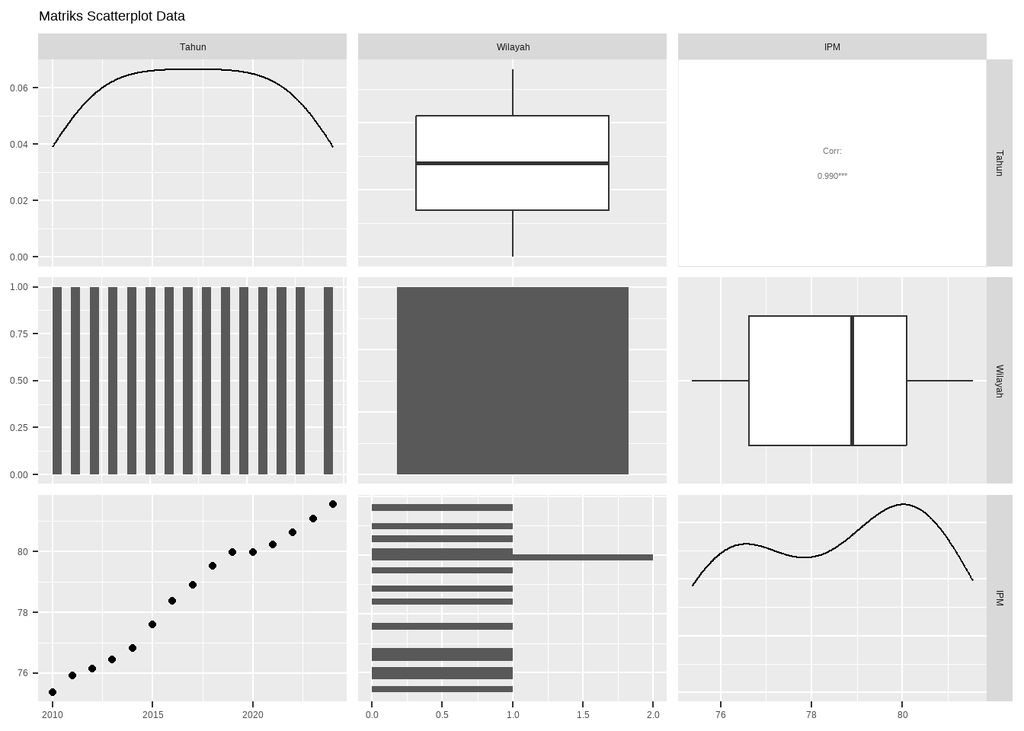

```r
ggpairs(data,
        upper = list(continuous = wrap("cor", size = 3)),
        title = "Matriks Scatterplot Data")
```

Dari eksplorasi yang telah dilakukan, dapat dilihat data IPM D.I. Yogyakarta memiliki nilai korelasi 0.990

## Model Data IPM D.I. Yogyakarta

```r
model <- lm(IPM ~ Tahun, data = data)
summary(model)
```

```
##
## Call:
## lm(formula = IPM ~ Tahun, data = data)
##
## Residuals:
##      Min       1Q   Median       3Q      Max
## -0.39688 -0.19724 -0.07081  0.17508  0.51348
##
## Coefficients:
##              Estimate Std. Error t value Pr(>|t|)
## (Intercept) -837.0053    35.7084  -23.44 5.08e-12 ***
## Tahun          0.4539     0.0177   25.64 1.62e-12 ***
## ---
## Signif. codes:  0 '***' 0.001 '**' 0.01 '*' 0.05 '.' 0.1 ' ' 1
##
## Residual standard error: 0.2962 on 13 degrees of freedom
## Multiple R-squared:  0.9806, Adjusted R-squared:  0.9791
## F-statistic: 657.4 on 1 and 13 DF,  p-value: 1.621e-12
```

# Pengujian

## Uji Durbin Watson Test

```r
dwtest(model)
```

```
##
##  Durbin-Watson test
##
## data:  model
## DW = 0.54833, p-value = 4.291e-05
## alternative hypothesis: true autocorrelation is greater than 0
```

Berdasarkan hasil uji tes Durbin-Watson, diperoleh nilai $p-value$ sebesar 4.291e-05 yang di mana lebih kecil dari 0.05. Yang menandakan adanya korelasi pada data IPM D.I. Yogyakarta. Sehingga perlu ditangani.

## Plot ACF dan PACF

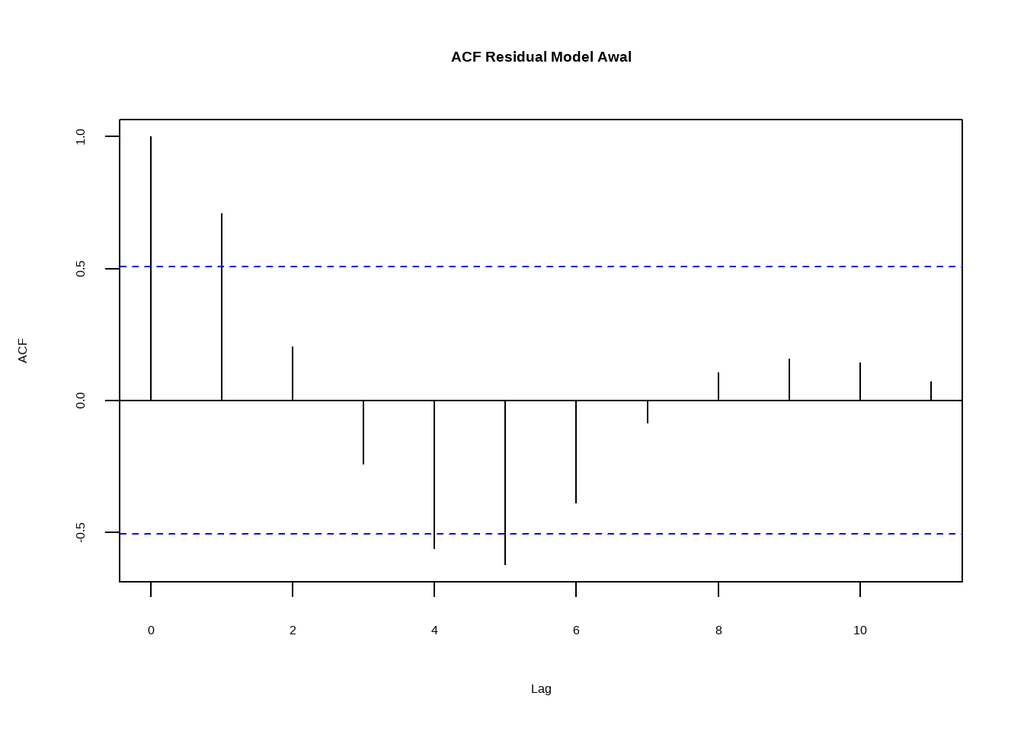

```r
acf(resid(model), main = "ACF Residual Model Awal")
```

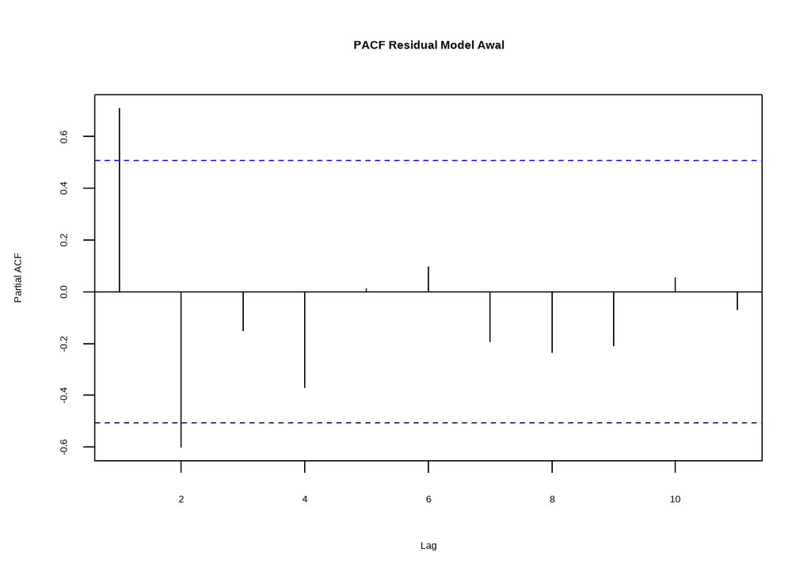

```r
pacf(resid(model), main = "PACF Residual Model Awal")
```

Tampak beberapa batang melewati batas signifikansi, artinya residual masih berkorelasi dengan periode sebelumnya. Ini alasan kenapa autokorelasi perlu ditangani.

# Penanganan Autokorelasi

## Metode Cochrane-Orcutt

Penanganan metode Cochrane-Orcutt dapat dilakukan dengan bantuan packages Orcutt pada aplikasi `R` maupun secara manual. Berikut ini ditampilkan cara menggunakan bantuan `library` *packages* `Orcutt`.

```r
#Penanganan Autokorelasi Cochrane-Orcutt
modelCO<-cochrane.orcutt(model)
modelCO
```

```
## Cochrane-orcutt estimation for first order autocorrelation
##
## Call:
## lm(formula = IPM ~ Tahun, data = data)
##
##  number of interaction: 9
##  rho 0.742439
##
## Durbin-Watson statistic
## (original):    0.54833 , p-value: 4.291e-05
## (transformed): 1.11266 , p-value: 1.458e-02
##
##  coefficients:
## (Intercept)       Tahun
## -793.902703    0.432578
```

Hasil keluaran model setelah dilakukan penanganan adalah sebagai berikut.
$$y_i=-793.902703+0.432578x_t$$
Hasil juga menunjukkan bahwa nilai DW dan p-value meningkat menjadi $1.11266$ dan $1.458e-02$. Hal tersebut juga didukung dengan nilai *p-value* < 0.05, artinya cukup bukti menyatakan bahwa sisaan terdapat autokorelasi pada taraf nyata 5%. Untuk nilai $ρ̂$ optimum yang digunakan adalah $0.742439$. Nilai tersebut dapat diketahui dengan *syntax* berikut.

```r
#Rho optimum
rho <- modelCO$rho
rho
```

```
## [1] 0.7424387
```

Selanjutnya akan dilakukan transformasi secara manual dengan syntax berikut ini.

```r
data$IPM
```

```
##  [1] 75.37 75.93 76.15 76.44 76.81 77.59 78.38 78.89 79.53 79.99 79.97 80.22
## [13] 80.64 81.07 81.55
```

```r
data$IPM[-1]
```

```
##  [1] 75.93 76.15 76.44 76.81 77.59 78.38 78.89 79.53 79.99 79.97 80.22 80.64
## [13] 81.07 81.55
```

```r
#Transformasi Manual
IPM.trans<- data$IPM[-1]-data$IPM[-15]*rho
Tahun.trans<- data$Tahun[-1]-data$Tahun[-15]*rho
modelCOmanual<- lm(IPM.trans~Tahun.trans)
summary(modelCOmanual)
```

```
##
## Call:
## lm(formula = IPM.trans ~ Tahun.trans)
##
## Residuals:
##     Min      1Q  Median      3Q     Max
## -0.3190 -0.1726 -0.0112  0.1481  0.3185
##
## Coefficients:
##               Estimate Std. Error t value Pr(>|t|)
## (Intercept) -204.47862   28.39877  -7.200 1.09e-05 ***
## Tahun.trans    0.43258    0.05457   7.926 4.13e-06 ***
## ---
## Signif. codes:  0 '***' 0.001 '**' 0.01 '*' 0.05 '.' 0.1 ' ' 1
##
## Residual standard error: 0.212 on 12 degrees of freedom
## Multiple R-squared:  0.8396, Adjusted R-squared:  0.8263
## F-statistic: 62.83 on 1 and 12 DF,  p-value: 4.132e-06
```

```r
#Mencari Penduga Koefisien Regresi setelah Transformasi ke Persamaan Awal
b0bintang <- modelCOmanual$coefficients[-2]
b0 <- b0bintang/(1-rho)
b1 <- modelCOmanual$coefficients[-1]
b0
```

```
## (Intercept)
##   -793.9027
```

```r
b1
```

```
## Tahun.trans
##   0.4325776
```

Hasil perhitungan koefisien regresi tersebut akan menghasilkan hasil yang sama dengan model yang dihasilkan menggunakan *packages*.

## Metode Hildreth-Lu

Penanganan kedua adalah menggunakan metode Hildreth-Lu. Metode ini akan mencari nilai SSE terkecil dan dapat dicari secara manual maupun menggunakan packages. Jika menggunakan packages, gunakan `library` *packages* `HORM`.

```r
# ambil y dan x (satu prediktor saja)
y <- data$IPM
x <- data$Tahun

# grid search rho 0–0.9
r <- seq(0, 0.9, by = 0.1)
tab <- data.frame(
  rho = r,
  SSE = sapply(r, function(rr) deviance(hildreth.lu(y, x, rr)))
)

tab            # tabel rho vs SSE
```

| rho | SSE |
| --- | --- |
| 0.0 | 1.1402611 |
| 0.1 | 0.9892946 |
| 0.2 | 0.8601303 |
| 0.3 | 0.7527681 |
| 0.4 | 0.6672080 |
| 0.5 | 0.6034501 |
| 0.6 | 0.5614943 |
| 0.7 | 0.5413407 |
| 0.8 | 0.5429893 |
| 0.9 | 0.5664399 |

```r
rho_hat <- tab$rho[which.min(tab$SSE)]   # rho terbaik
fit_hl  <- hildreth.lu(y, x, rho_hat)    # model final
summary(fit_hl)
```

```
##
## Call:
## lm(formula = y ~ x)
##
## Residuals:
##      Min       1Q   Median       3Q      Max
## -0.29853 -0.18222 -0.02237  0.16615  0.31529
##
## Coefficients:
##               Estimate Std. Error t value Pr(>|t|)
## (Intercept) -240.55680   28.44267  -8.458 2.12e-06 ***
## x              0.43651    0.04694   9.300 7.80e-07 ***
## ---
## Signif. codes:  0 '***' 0.001 '**' 0.01 '*' 0.05 '.' 0.1 ' ' 1
##
## Residual standard error: 0.2124 on 12 degrees of freedom
## Multiple R-squared:  0.8782, Adjusted R-squared:  0.868
## F-statistic: 86.48 on 1 and 12 DF,  p-value: 7.803e-07
```

```r
#Penanganan Autokorelasi Hildreth lu
# Hildreth-Lu
hildreth.lu.func<- function(r, model){
  x <- model.matrix(model)[,-1]
  y <- model.response(model.frame(model))
  n <- length(y)
  t <- 2:n
  y <- y[t]-r*y[t-1]
  x <- x[t]-r*x[t-1]

  return(lm(y~x))
}

#Pencariab rho yang meminimumkan SSE
r <- c(seq(0.1,0.9, by= 0.1))
tab <- data.frame("rho" = r, "SSE" = sapply(r, function(i){deviance(hildreth.lu.func(i, model))}))
round(tab, 4)
```

| rho | SSE |
| --- | --- |
| 0.1 | 0.9893 |
| 0.2 | 0.8601 |
| 0.3 | 0.7528 |
| 0.4 | 0.6672 |
| 0.5 | 0.6035 |
| 0.6 | 0.5615 |
| 0.7 | 0.5413 |
| 0.8 | 0.5430 |
| 0.9 | 0.5664 |

```r
#Rho optimal di sekitar 0.7
rOpt <- seq(0.74243,0.74245, by= 0.0000001)
tabOpt <- data.frame("rho" = rOpt, "SSE" = sapply(rOpt, function(i){deviance(hildreth.lu.func(i, model))}))
head(tabOpt[order(tabOpt$SSE),])
```

|  | rho | SSE |
| --- | --- | --- |
| 86 | 0.7424385 | 0.5393774 |
| 87 | 0.7424386 | 0.5393774 |
| 90 | 0.7424389 | 0.5393774 |
| 88 | 0.7424387 | 0.5393774 |
| 89 | 0.7424388 | 0.5393774 |
| 85 | 0.7424384 | 0.5393774 |

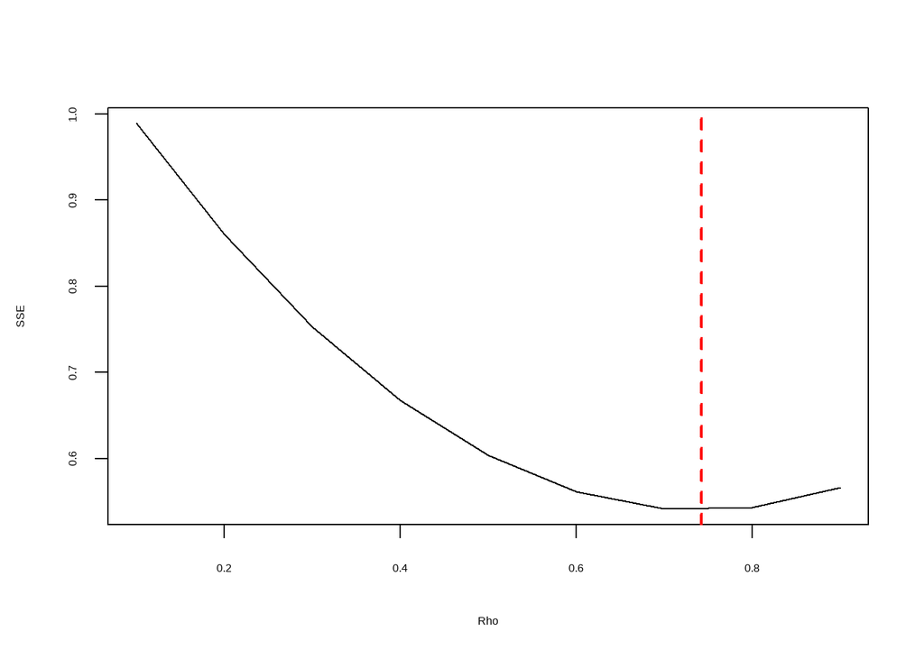

```r
#Grafik SSE optimum
par(mfrow = c(1,1))
plot(tab$SSE ~ tab$rho , type = "l", xlab = "Rho", ylab = "SSE")
abline(v = tabOpt[tabOpt$SSE==min(tabOpt$SSE),"rho"], lty = 2, col="red",lwd=2)
text(x=0.341, y=0.2397500, labels = "rho=0.7424385", cex = 0.8)
```

Perhitungan yang dilakukan aplikasi `R` menunjukkan bahwa nilai $ρ$ optimum, yaitu saat SSE terkecil terdapat pada nilai $ρ=0.7424385$. Hal tersebut juga ditunjukkan pada plot. Selanjutnya, model dapat didapatkan dengan mengevaluasi nilai $ρ$ ke dalam fungsi `hildreth.lu.func`, serta dilanjutkan dengan pengujian autokorelasi dengan uji Durbin-Watson. Namun, setelah pengecekan tersebut tidak lupa koefisien regresi tersebut digunakan untuk transformasi balik. Persamaan hasil transformasi itulah yang menjadi persamaan sesungguhnya.

```r
#Model terbaik
modelHL <- hildreth.lu.func(0.7424385, model)
summary(modelHL)
```

```
##
## Call:
## lm(formula = y ~ x)
##
## Residuals:
##     Min      1Q  Median      3Q     Max
## -0.3190 -0.1726 -0.0112  0.1481  0.3185
##
## Coefficients:
##               Estimate Std. Error t value Pr(>|t|)
## (Intercept) -204.47878   28.39877  -7.200 1.09e-05 ***
## x              0.43258    0.05457   7.926 4.13e-06 ***
## ---
## Signif. codes:  0 '***' 0.001 '**' 0.01 '*' 0.05 '.' 0.1 ' ' 1
##
## Residual standard error: 0.212 on 12 degrees of freedom
## Multiple R-squared:  0.8396, Adjusted R-squared:  0.8263
## F-statistic: 62.83 on 1 and 12 DF,  p-value: 4.132e-06
```

```r
#Transformasi Balik
cat("y = ", coef(modelHL)[1]/(1-0.7424385), "+", coef(modelHL)[2],"x", sep = "")
```

```
## y = -793.9027+0.4325776x
```

Setelah dilakukan tranformasi balik, didapatkan model dengan metode Hildreth-Lu sebagai berikut.
$$y_i=-793.9027+0.4325776x_t$$

```r
#Deteksi autokorelasi
dwtest(modelHL)
```

```
##
##  Durbin-Watson test
##
## data:  modelHL
## DW = 1.1127, p-value = 0.01458
## alternative hypothesis: true autocorrelation is greater than 0
```

Terakhir, akan dibandingkan nilai SSE dari ketiga metode (metode awal, metode Cochrane-Orcutt, dan Hildreth-Lu).

```r
#Perbandingan
sseModelawal <- anova(model)$`Sum Sq`[-1]
sseModelCO <- anova(modelCOmanual)$`Sum Sq`[-1]
sseModelHL <- anova(modelHL)$`Sum Sq`[-1]
mseModelawal <- sseModelawal/length(data$IPM)
mseModelCO <- sseModelCO/length(data$IPM)
mseModelHL <- sseModelHL/length(data$IPM)
akurasi <- matrix(c(sseModelawal,sseModelCO,sseModelHL,
                    mseModelawal,mseModelCO,mseModelHL),nrow=2,ncol=3,byrow = T)
colnames(akurasi) <- c("Model Awal", "Model Cochrane-Orcutt", "Model Hildreth-Lu")
row.names(akurasi) <- c("SSE","MSE")
akurasi
```

```
##     Model Awal Model Cochrane-Orcutt Model Hildreth-Lu
## SSE 1.14085190            0.53937740        0.53937740
## MSE 0.07605679            0.03595849        0.03595849
```

# Simpulan

- Model awal (OLS) menunjukkan adanya autokorelasi (DW test p < 0.05).
- Plot ACF & PACF residual juga menguatkan bahwa residual masih saling berkorelasi.
- Penanganan dengan Cochrane-Orcutt dan Hildreth-Lu menghasilkan model yang hampir sama dengan rho optimum sekitar 0.742.
- SSE dan MSE setelah penanganan lebih baik dibandingkan model awal.
- Namun, uji DW menunjukkan masih ada autokorelasi tersisa → artinya model AR(1) saja mungkin belum cukup.